# 02b · 时间序列可视化：美观版

适合把探索结果放进研究汇报。与基础版的 V01–V18 使用**相同的小表和分析任务**，这里编号为 S01–S18，便于对照绘图写法。

仍然按 **输入表 → 要做什么 → 代码 → 图形结果** 阅读，每例只画一张图，使用 `plt.figure()`、`plt.plot()`、`plt.title()` 等写法。

**怎么用：**

1. 先运行下面的主题初始化格，统一导入库、配色、字体和网格。
2. 找到案例，检查自己的 `df` 是否具有表中列名和单位。
3. 已有 `df` 时跳过示例建表，直接复制绘图格；练习时先运行该例的示例建表格。

这里的配色和标注用于突出信息：数值写单位、关键点带标签、同类图保持一致。代码没有自定义绘图函数，每个样式都能在代码中直接修改。

全部小表均为人工构造的教学数据，并非真实市场行情。示例表只有 8–10 行，用于理解代码，不能据此判断市场规律。收益 `0.01` 表示 `1%`；缺失仍是缺失。图内使用英文和环境自带字体，中文解释保留在表格与代码旁。

| 想做什么 | 案例 |
| --- | --- |
| 展示收益、比较两条走势 | S01–S02 |
| 缺失位置、缺失率、收益分布、极端值 | S03–S06 |
| 滚动波动、滚动相关、相关矩阵 | S07–S09 |
| 滞后关系、自相关、星期与月度比较 | S10–S13 |
| 成交量、训练测试边界、分组收益 | S14–S16 |
| 回撤、每小时事件数 | S17–S18 |

```python
# SETUP：只需运行一次。之后每个案例使用自己的 df。
import numpy as np
import pandas as pd
import matplotlib.pyplot as plt
from matplotlib.colors import ListedColormap
from IPython.display import display

BLUE = "#2563EB"
TEAL = "#0F766E"
ORANGE = "#D97706"
RED = "#DC2626"
INK = "#1E293B"
MUTED = "#64748B"
LIGHT = "#E2E8F0"

plt.rcdefaults()
plt.rcParams.update({
    "font.family": "DejaVu Sans", "font.size": 11,
    "figure.dpi": 120, "savefig.dpi": 200,
    "figure.facecolor": "white", "axes.facecolor": "white",
    "axes.spines.top": False, "axes.spines.right": False,
    "axes.edgecolor": LIGHT, "axes.linewidth": 0.8,
    "axes.titlelocation": "left", "axes.titlesize": 15,
    "axes.titleweight": "bold", "axes.titlecolor": INK, "axes.titlepad": 16,
    "axes.labelcolor": MUTED, "axes.labelpad": 8,
    "xtick.color": MUTED, "ytick.color": MUTED,
    "xtick.labelsize": 10, "ytick.labelsize": 10,
    "axes.grid": True, "axes.grid.axis": "y", "axes.axisbelow": True,
    "grid.color": LIGHT, "grid.linewidth": 0.7, "grid.alpha": 0.7,
    "lines.linewidth": 2.2, "legend.frameon": False,
})
```

## S01 · 日收益：看收益随时间怎样变化

**输入表：`df`（全部 8 行）**

| date | ret |
| --- | --- |
| 2024-01-02 | 0.01 |
| 2024-01-03 | -0.015 |
| 2024-01-04 | 0.006 |
| 2024-01-05 | 0.022 |
| 2024-01-08 | -0.008 |
| 2024-01-09 | 0.004 |
| 2024-01-10 | -0.025 |
| 2024-01-11 | 0.012 |

date 是交易日期；ret 是当天收益率，用小数表示，0.01 就是 1%。每个日期一行。

**要做什么：** 画出日收益折线，并画一条 0% 水平线，观察正负收益与大幅波动出现在哪天。

**代码：** 已有同列名的 `df` 时，跳过第一个示例建表格，复制第二个绘图格。

```python
# 示例建表：已有自己的 df 时跳过。
df = pd.DataFrame([
    ['2024-01-02', 0.01],
    ['2024-01-03', -0.015],
    ['2024-01-04', 0.006],
    ['2024-01-05', 0.022],
    ['2024-01-08', -0.008],
    ['2024-01-09', 0.004],
    ['2024-01-10', -0.025],
    ['2024-01-11', 0.012],
], columns=['date', 'ret'])
```

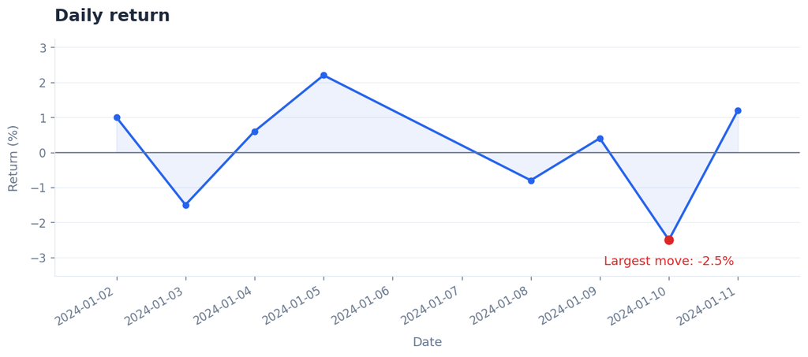

```python
# 绘图代码：先运行本册主题初始化格。
df["date"] = pd.to_datetime(df["date"])
df = df.sort_values("date").reset_index(drop=True)
returns_pct = df["ret"] * 100  # 保持缺失值；单位改为百分数

plt.figure(figsize=(10, 4.5))
plt.plot(df["date"], returns_pct, color=BLUE, marker="o", markersize=5, linewidth=2)
plt.fill_between(df["date"].to_numpy(), returns_pct.to_numpy(), 0, color=BLUE, alpha=0.08)
plt.axhline(0, color=MUTED, linewidth=1)
if returns_pct.notna().any():  # 只标出一个重点，避免文字挤满图
    peak = returns_pct.abs().idxmax()
    plt.scatter(df.loc[peak, "date"], returns_pct.loc[peak], color=RED, s=55, zorder=3)
    plt.annotate("Largest move: {:+.1f}%".format(returns_pct.loc[peak]),
                 xy=(df.loc[peak, "date"], returns_pct.loc[peak]),
                 xytext=(0, 14 if returns_pct.loc[peak] > 0 else -22),
                 textcoords="offset points", ha="center", color=RED)
plt.title("Daily return")
plt.xlabel("Date")
plt.ylabel("Return (%)")
plt.xticks(rotation=30, ha="right")
plt.margins(x=0.10, y=0.22)
plt.tight_layout()
plt.show()
```

**美化了哪里：** 蓝色折线搭配淡色面积，以红色标注绝对收益最大的日期，先看整体路径，再找到重点。

**图怎么读：** 1 月 5 日收益为 +2.2%，1 月 10 日为 -2.5%；水平线帮助区分上涨和下跌。

**换数据时注意：** 收益已有百分数数值（例如 1 表示 1%）时，不要再乘以 100。

## S02 · 两只资产：从相同起点比较价格变化

**输入表：`df`（全部 8 行）**

| date | asset_a | asset_b |
| --- | --- | --- |
| 2024-01-02 | 100 | 50 |
| 2024-01-03 | 102 | 49 |
| 2024-01-04 | 101 | 51 |
| 2024-01-05 | 104 | 52 |
| 2024-01-08 | 103 | 53 |
| 2024-01-09 | 106 | 52 |
| 2024-01-10 | 108 | 54 |
| 2024-01-11 | 110 | 53 |

date 是共同交易日期；asset_a、asset_b 是两只资产的正价格；这个模板要求两列日期对齐且没有缺失值。

**要做什么：** 把两只资产第一天的价格都设为 100，放在同一张折线图里比较区间表现。

**代码：** 已有同列名的 `df` 时，跳过第一个示例建表格，复制第二个绘图格。

```python
# 示例建表：已有自己的 df 时跳过。
df = pd.DataFrame([
    ['2024-01-02', 100, 50],
    ['2024-01-03', 102, 49],
    ['2024-01-04', 101, 51],
    ['2024-01-05', 104, 52],
    ['2024-01-08', 103, 53],
    ['2024-01-09', 106, 52],
    ['2024-01-10', 108, 54],
    ['2024-01-11', 110, 53],
], columns=['date', 'asset_a', 'asset_b'])
```

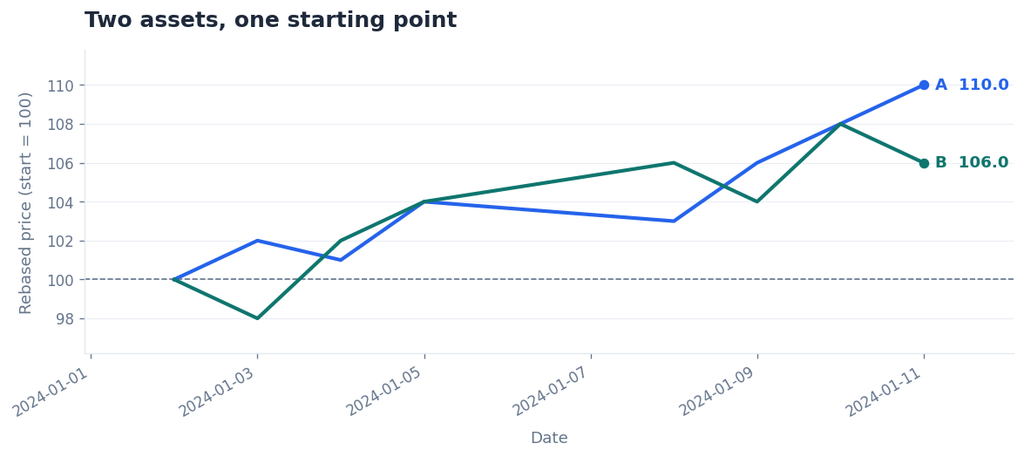

```python
# 绘图代码：先运行本册主题初始化格。
df["date"] = pd.to_datetime(df["date"])
df = df.sort_values("date")
prices = df.set_index("date")[["asset_a", "asset_b"]]
rebased = prices / prices.iloc[0] * 100  # 输入要求价格为正且无缺失，共同起点为 100

plt.figure(figsize=(10, 4.5))
plt.axhline(100, color=MUTED, linewidth=1, linestyle="--")
for column, label, color in [("asset_a", "A", BLUE), ("asset_b", "B", TEAL)]:
    plt.plot(rebased.index, rebased[column], color=color, linewidth=2.5)
    last_value = rebased[column].iloc[-1]
    plt.scatter(rebased.index[-1], last_value, color=color, s=35, zorder=3)
    plt.annotate("{}  {:.1f}".format(label, last_value),
                 xy=(rebased.index[-1], last_value), xytext=(8, 0),
                 textcoords="offset points", va="center", color=color, fontweight="bold")
plt.title("Two assets, one starting point")
plt.xlabel("Date")
plt.ylabel("Rebased price (start = 100)")
plt.xticks(rotation=30, ha="right")
plt.margins(x=0.12, y=0.15)  # 为末端文字留空间
plt.tight_layout()
plt.show()
```

**美化了哪里：** 用蓝绿两色区分资产，保留共同起点参考线，在曲线末端直接显示资产名称与最终数值。

**图怎么读：** 最后一天 A 为 110、B 为 106，表示相对共同起点，价格分别上涨 10% 和 6%。

**换数据时注意：** 比较投资表现时优先使用口径一致的复权价格；本例价格变化不包含手续费。

## S03 · 缺失热图：看哪些日期、哪些列缺数据

**输入表：`df`（全部 8 行）**

| date | A | B | C |
| --- | --- | --- | --- |
| 2024-01-02 | 100 | 50 | 80 |
| 2024-01-03 | 101 | NaN | 81 |
| 2024-01-04 | 102 | NaN | 82 |
| 2024-01-05 | NaN | 52 | 83 |
| 2024-01-08 | 104 | 53 | NaN |
| 2024-01-09 | 105 | 54 | NaN |
| 2024-01-10 | 106 | 55 | NaN |
| 2024-01-11 | 107 | 56 | 87 |

date 按预期交易日每天一行；A、B、C 是待检查的数值列；空白表示缺失。整日缺数据也必须保留那一行。

**要做什么：** 用热图标出缺失位置：每一行是一个日期，每一列是一个字段，黄色代表缺失。

**代码：** 已有同列名的 `df` 时，跳过第一个示例建表格，复制第二个绘图格。

```python
# 示例建表：已有自己的 df 时跳过。
df = pd.DataFrame([
    ['2024-01-02', 100, 50, 80],
    ['2024-01-03', 101, None, 81],
    ['2024-01-04', 102, None, 82],
    ['2024-01-05', None, 52, 83],
    ['2024-01-08', 104, 53, None],
    ['2024-01-09', 105, 54, None],
    ['2024-01-10', 106, 55, None],
    ['2024-01-11', 107, 56, 87],
], columns=['date', 'A', 'B', 'C'])
```

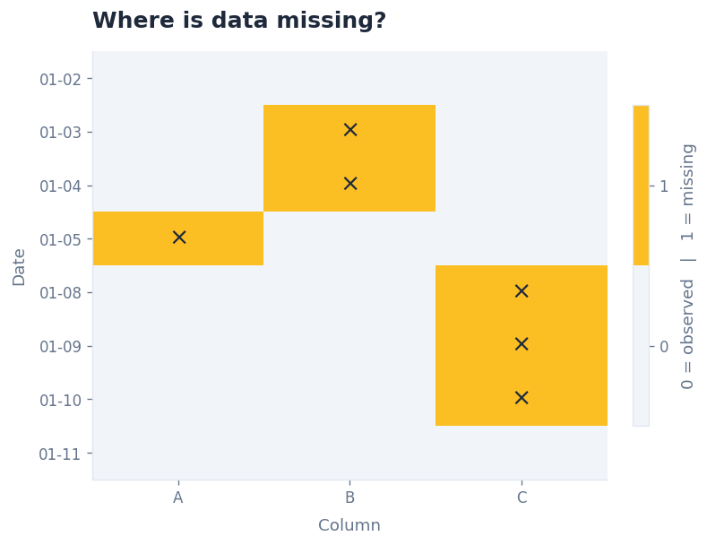

```python
# 绘图代码：先运行本册主题初始化格。
df["date"] = pd.to_datetime(df["date"])
df = df.sort_values("date")
values = df.set_index("date")[["A", "B", "C"]]
missing = values.isna()

plt.figure(figsize=(7, 5.2))
plt.grid(False)  # 热图不叠加默认的水平网格线
plt.imshow(missing, aspect="auto", cmap=ListedColormap(["#F1F5F9", "#FBBF24"]),
           vmin=-0.5, vmax=1.5, interpolation="nearest")
plt.xticks(range(len(values.columns)), values.columns)
plt.yticks(range(len(values)), values.index.strftime("%m-%d"))
for row, column in zip(*np.where(missing.to_numpy())):
    plt.text(column, row, "×", ha="center", va="center", color=INK, fontsize=16)
plt.colorbar(ticks=[0, 1], label="0 = observed   |   1 = missing", shrink=0.75, pad=0.04)
plt.title("Where is data missing?")
plt.xlabel("Column")
plt.ylabel("Date")
plt.tight_layout()
plt.show()
```

**美化了哪里：** 用浅灰与黄色两个离散颜色区分完整与缺失，只在缺失格子写 ×，避免把有无缺失误读为连续数值。

**图怎么读：** B 在 1 月 3–4 日连续缺失，C 在 1 月 8–10 日连续缺失，A 只有 1 月 5 日缺失。

**换数据时注意：** 如果某个日期整行不存在，isna() 看不到它；先按正确的交易日历补齐日期。

## S04 · 缺失率：快速比较哪些字段最不完整

**输入表：`df`（全部 8 行）**

| date | A | B | C |
| --- | --- | --- | --- |
| 2024-01-02 | 100 | 50 | 80 |
| 2024-01-03 | 101 | NaN | 81 |
| 2024-01-04 | 102 | NaN | 82 |
| 2024-01-05 | NaN | 52 | 83 |
| 2024-01-08 | 104 | 53 | NaN |
| 2024-01-09 | 105 | 54 | NaN |
| 2024-01-10 | 106 | 55 | NaN |
| 2024-01-11 | 107 | 56 | 87 |

每行对应一个预期交易日；A、B、C 是数值字段；缺失率的分母为这张表的全部行数。

**要做什么：** 计算 A、B、C 三列各自的缺失比例，按从高到低画柱状图。

**代码：** 已有同列名的 `df` 时，跳过第一个示例建表格，复制第二个绘图格。

```python
# 示例建表：已有自己的 df 时跳过。
df = pd.DataFrame([
    ['2024-01-02', 100, 50, 80],
    ['2024-01-03', 101, None, 81],
    ['2024-01-04', 102, None, 82],
    ['2024-01-05', None, 52, 83],
    ['2024-01-08', 104, 53, None],
    ['2024-01-09', 105, 54, None],
    ['2024-01-10', 106, 55, None],
    ['2024-01-11', 107, 56, 87],
], columns=['date', 'A', 'B', 'C'])
```

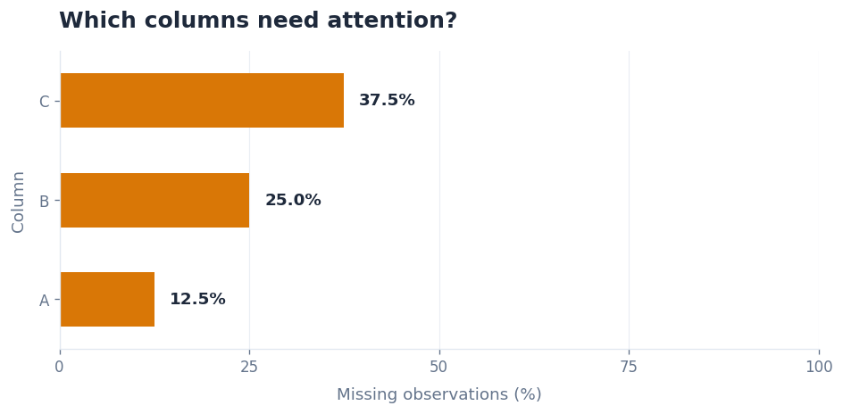

```python
# 绘图代码：先运行本册主题初始化格。
missing_pct = df[["A", "B", "C"]].isna().mean().sort_values(ascending=False) * 100

plt.figure(figsize=(8, 4))
plt.barh(missing_pct.index, missing_pct.values, color=ORANGE, height=0.55)
plt.ylim(len(missing_pct) - 0.5, -0.5)  # 将最高缺失率放在最上方
for row, value in enumerate(missing_pct):
    plt.text(min(value + 2, 98), row, "{:.1f}%".format(value), va="center",
             ha="right" if value > 94 else "left", color=INK, fontweight="bold")
plt.title("Which columns need attention?")
plt.xlabel("Missing observations (%)")
plt.ylabel("Column")
plt.xlim(0, 100)  # 缺失率使用完整的百分数范围
plt.xticks([0, 25, 50, 75, 100])
plt.grid(False, axis="y")
plt.grid(True, axis="x", color=LIGHT, linewidth=0.7)
plt.tight_layout()
plt.show()
```

**美化了哪里：** 改为从高到低的横向条形图，统一 0–100% 刻度，并在条形末端直接写出缺失比例。

**图怎么读：** C 缺失 3/8 = 37.5%，B 缺失 25%，A 缺失 12.5%；可先检查 C 的来源与覆盖范围。

**换数据时注意：** 缺失率高不代表必须删列；先分清尚未上市、休市、无成交和采集失败。

## S05 · 收益分布：看收益主要落在哪个范围

**输入表：`df`（全部 8 行）**

| ret |
| --- |
| -0.025 |
| -0.015 |
| -0.008 |
| 0.004 |
| 0.006 |
| 0.01 |
| 0.012 |
| 0.022 |

ret 是每个观测期的收益率，小数单位；所有行应采用相同的收益周期，例如全部为日收益。

**要做什么：** 把日收益画成直方图，横轴用百分数，纵轴表示落入该区间的观测数量。

**代码：** 已有同列名的 `df` 时，跳过第一个示例建表格，复制第二个绘图格。

```python
# 示例建表：已有自己的 df 时跳过。
df = pd.DataFrame([
    [-0.025],
    [-0.015],
    [-0.008],
    [0.004],
    [0.006],
    [0.01],
    [0.012],
    [0.022],
], columns=['ret'])
```

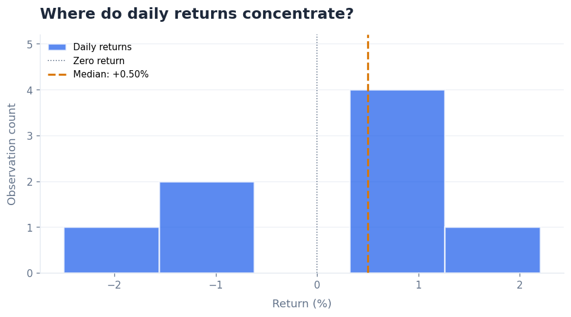

```python
# 绘图代码：先运行本册主题初始化格。
returns_pct = df["ret"].dropna() * 100  # 不将缺失收益替换成 0
median_pct = returns_pct.median()

plt.figure(figsize=(8, 4.5))
plt.hist(returns_pct, bins=5, color=BLUE, alpha=0.75,
         edgecolor="white", linewidth=1.5, label="Daily returns")
plt.axvline(0, color=MUTED, linewidth=1, linestyle=":", label="Zero return")
if pd.notna(median_pct):
    plt.axvline(median_pct, color=ORANGE, linewidth=2, linestyle="--",
                label="Median: {:+.2f}%".format(median_pct))
plt.title("Where do daily returns concentrate?")
plt.xlabel("Return (%)")
plt.ylabel("Observation count")
plt.legend(loc="upper left", fontsize=9)
plt.margins(y=0.30)  # 给图例留出空间
plt.tight_layout()
plt.show()
```

**美化了哪里：** 以低饱和蓝色直方图展示分布，增加橙色中位数线，参考线与图例帮助定位中心。

**图怎么读：** 柱子的高度表示样本在各收益区间的数量；这个小例子同时包含正收益和负收益。

**换数据时注意：** 8 行只用于演示语法；真实分布分析需要更多样本，分箱数量也会影响外观。

## S06 · 大幅波动：标出绝对收益超过 2% 的日期

**输入表：`df`（全部 8 行）**

| date | ret |
| --- | --- |
| 2024-01-02 | 0.01 |
| 2024-01-03 | -0.015 |
| 2024-01-04 | 0.006 |
| 2024-01-05 | 0.022 |
| 2024-01-08 | -0.008 |
| 2024-01-09 | 0.004 |
| 2024-01-10 | -0.025 |
| 2024-01-11 | 0.012 |

date 是日期，ret 是小数单位的日收益；阈值 0.02 表示 2%。

**要做什么：** 画日收益折线，并用红点突出绝对收益大于 2% 的观测，方便回查原始数据。

**代码：** 已有同列名的 `df` 时，跳过第一个示例建表格，复制第二个绘图格。

```python
# 示例建表：已有自己的 df 时跳过。
df = pd.DataFrame([
    ['2024-01-02', 0.01],
    ['2024-01-03', -0.015],
    ['2024-01-04', 0.006],
    ['2024-01-05', 0.022],
    ['2024-01-08', -0.008],
    ['2024-01-09', 0.004],
    ['2024-01-10', -0.025],
    ['2024-01-11', 0.012],
], columns=['date', 'ret'])
```

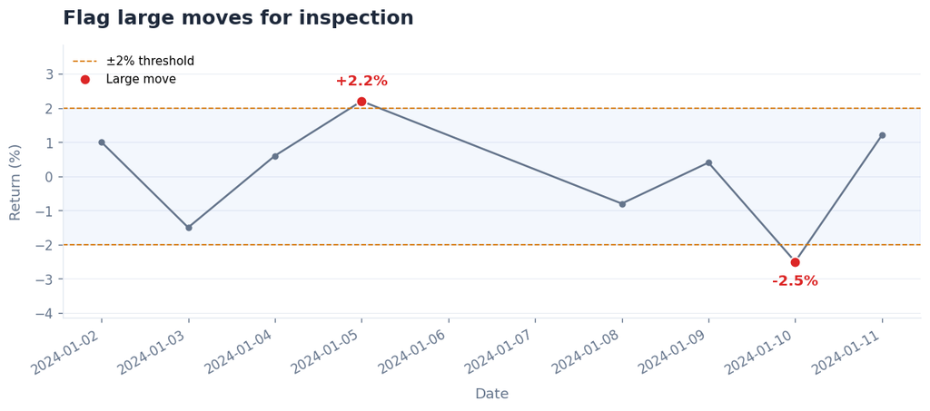

```python
# 绘图代码：先运行本册主题初始化格。
df["date"] = pd.to_datetime(df["date"])
df = df.sort_values("date")
large_move = df["ret"].abs() > 0.02  # 固定阈值：2%

plt.figure(figsize=(10, 4.5))
plt.plot(df["date"], df["ret"] * 100, color=MUTED, linewidth=1.5, marker="o", markersize=4)
plt.axhspan(-2, 2, color=BLUE, alpha=0.05)  # 淡色背景表示阈值以内
plt.axhline(2, color=ORANGE, linewidth=1, linestyle="--", label="±2% threshold")
plt.axhline(-2, color=ORANGE, linewidth=1, linestyle="--")
plt.scatter(df.loc[large_move, "date"], df.loc[large_move, "ret"] * 100,
            color=RED, s=65, edgecolors="white", zorder=3, label="Large move")
for date, ret in df.loc[large_move, ["date", "ret"]].itertuples(index=False, name=None):
    plt.annotate("{:+.1f}%".format(ret * 100), xy=(date, ret * 100),
                 xytext=(0, 12 if ret > 0 else -18), textcoords="offset points",
                 ha="center", color=RED, fontweight="bold")
plt.title("Flag large moves for inspection")
plt.xlabel("Date")
plt.ylabel("Return (%)")
plt.xticks(rotation=30, ha="right")
plt.legend(loc="upper left", fontsize=9)
plt.margins(x=0.05, y=0.35)
plt.tight_layout()
plt.show()
```

**美化了哪里：** 用浅灰折线作为背景，只将越过 ±2% 阈值的点和数值标为红色，把注意力集中到需要检查的日期。

**图怎么读：** 红点对应 1 月 5 日的 +2.2% 和 1 月 10 日的 -2.5%，是优先回查的日期。

**换数据时注意：** 大幅波动可能是真实行情，不能仅凭超过阈值就认定错误或删除。

## S07 · 滚动波动：看近期收益是否越来越不稳定

**输入表：`df`（全部 8 行）**

| date | ret |
| --- | --- |
| 2024-01-02 | 0.002 |
| 2024-01-03 | -0.003 |
| 2024-01-04 | 0.004 |
| 2024-01-05 | -0.002 |
| 2024-01-08 | 0.02 |
| 2024-01-09 | -0.025 |
| 2024-01-10 | 0.03 |
| 2024-01-11 | -0.018 |

date 是交易日期；ret 是小数单位的日收益；每个交易日只有一行。

**要做什么：** 计算过去 3 个观测的日收益样本标准差，画折线观察波动水平的变化，不做年化。

**代码：** 已有同列名的 `df` 时，跳过第一个示例建表格，复制第二个绘图格。

```python
# 示例建表：已有自己的 df 时跳过。
df = pd.DataFrame([
    ['2024-01-02', 0.002],
    ['2024-01-03', -0.003],
    ['2024-01-04', 0.004],
    ['2024-01-05', -0.002],
    ['2024-01-08', 0.02],
    ['2024-01-09', -0.025],
    ['2024-01-10', 0.03],
    ['2024-01-11', -0.018],
], columns=['date', 'ret'])
```

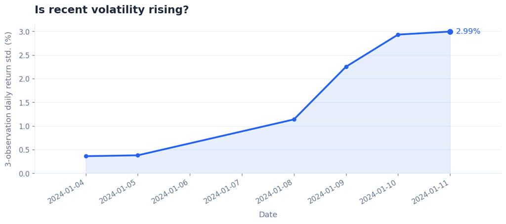

```python
# 绘图代码：先运行本册主题初始化格。
df["date"] = pd.to_datetime(df["date"])
df = df.sort_values("date").reset_index(drop=True)
rolling_std_pct = df["ret"].rolling(3, min_periods=3).std() * 100  # ddof=1，未年化

plt.figure(figsize=(10, 4.5))
plt.plot(df["date"], rolling_std_pct, color=BLUE, linewidth=2.5, marker="o", markersize=5)
plt.fill_between(df["date"].to_numpy(), rolling_std_pct.to_numpy(), 0, color=BLUE, alpha=0.10)
last = rolling_std_pct.last_valid_index()  # 前两行仍保持缺失，不补成 0
if last is not None:
    plt.scatter(df.loc[last, "date"], rolling_std_pct.loc[last], color=BLUE, s=50, zorder=3)
    plt.annotate("{:.2f}%".format(rolling_std_pct.loc[last]),
                 xy=(df.loc[last, "date"], rolling_std_pct.loc[last]),
                 xytext=(8, 0), textcoords="offset points", va="center", color=BLUE)
plt.title("Is recent volatility rising?")
plt.xlabel("Date")
plt.ylabel("3-observation daily return std. (%)")
plt.ylim(bottom=0)
plt.xticks(rotation=30, ha="right")
plt.margins(x=0.14, y=0.20)
plt.tight_layout()
plt.show()
```

**美化了哪里：** 用蓝色曲线与浅色面积突出波动水平，纵轴从 0 开始，并在最后一个有效观测旁标出数值。

**图怎么读：** 前两行因观测不足没有结果；后半段收益振幅增大，滚动标准差明显上升。

**换数据时注意：** 窗口 3 仅供小表演示，实际常改为 20 或 60；它数的是观测行，不是日历天。

## S08 · 滚动相关：看两只资产的联动是否变化

**输入表：`df`（全部 8 行）**

| date | ret_a | ret_b |
| --- | --- | --- |
| 2024-01-02 | 0.01 | 0.008 |
| 2024-01-03 | -0.01 | -0.009 |
| 2024-01-04 | 0.02 | 0.017 |
| 2024-01-05 | -0.02 | -0.016 |
| 2024-01-08 | 0.015 | -0.014 |
| 2024-01-09 | -0.015 | 0.016 |
| 2024-01-10 | 0.025 | -0.02 |
| 2024-01-11 | -0.025 | 0.022 |

date 是双方共同交易日期；ret_a、ret_b 是同期日收益率，小数单位，按日期一一对应。

**要做什么：** 计算两只资产最近 3 个观测的相关系数，画出联动从同向到反向的变化。

**代码：** 已有同列名的 `df` 时，跳过第一个示例建表格，复制第二个绘图格。

```python
# 示例建表：已有自己的 df 时跳过。
df = pd.DataFrame([
    ['2024-01-02', 0.01, 0.008],
    ['2024-01-03', -0.01, -0.009],
    ['2024-01-04', 0.02, 0.017],
    ['2024-01-05', -0.02, -0.016],
    ['2024-01-08', 0.015, -0.014],
    ['2024-01-09', -0.015, 0.016],
    ['2024-01-10', 0.025, -0.02],
    ['2024-01-11', -0.025, 0.022],
], columns=['date', 'ret_a', 'ret_b'])
```

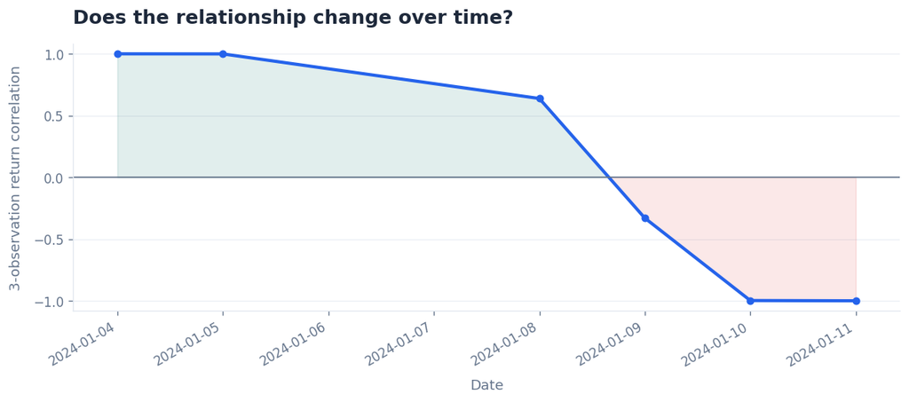

```python
# 绘图代码：先运行本册主题初始化格。
df["date"] = pd.to_datetime(df["date"])
df = df.sort_values("date")
rolling_corr = df["ret_a"].rolling(3, min_periods=3).corr(df["ret_b"])
x = df["date"].to_numpy()
y = rolling_corr.to_numpy()  # NaN 保持缺失，不补成 0

plt.figure(figsize=(10, 4.5))
plt.fill_between(x, y, 0, where=y >= 0, color=TEAL, alpha=0.12, interpolate=True)
plt.fill_between(x, y, 0, where=y < 0, color=RED, alpha=0.10, interpolate=True)
plt.plot(x, y, color=BLUE, linewidth=2.5, marker="o", markersize=5)
plt.axhline(0, color=MUTED, linewidth=1)
plt.ylim(-1.08, 1.08)  # 略留空间防止 ±1 处的标记被裁切
plt.yticks([-1, -0.5, 0, 0.5, 1])
plt.title("Does the relationship change over time?")
plt.xlabel("Date")
plt.ylabel("3-observation return correlation")
plt.xticks(rotation=30, ha="right")
plt.margins(x=0.06)
plt.tight_layout()
plt.show()
```

**美化了哪里：** 以蓝色相关曲线展示变化，用绿、红淡色面积区分正相关和负相关，并固定相关系数的刻度范围。

**图怎么读：** 前半段相关系数接近 +1，后半段接近 -1；这组演示数据刻意展示联动方向变化。

**换数据时注意：** 3 对观测的相关性非常不稳定；实际应扩大窗口，窗口内不足 3 对或某列恒定时结果为缺失。

## S09 · 相关矩阵：比较多只资产的同期收益关系

**输入表：`df`（全部 8 行）**

| A | B | C |
| --- | --- | --- |
| 0.01 | 0.008 | -0.009 |
| -0.01 | -0.007 | 0.008 |
| 0.02 | 0.016 | -0.012 |
| -0.02 | -0.015 | 0.019 |
| 0.015 | NaN | -0.01 |
| -0.015 | -0.009 | NaN |
| 0.025 | 0.019 | -0.021 |
| -0.025 | -0.018 | 0.024 |

每一行代表同一个交易日，A、B、C 是三只资产的小数日收益；列间已按日期对齐，空白为缺失。

**要做什么：** 先列出每两列共同非空的样本数，再画收益相关系数热图，比较正相关与负相关。

**代码：** 已有同列名的 `df` 时，跳过第一个示例建表格，复制第二个绘图格。

```python
# 示例建表：已有自己的 df 时跳过。
df = pd.DataFrame([
    [0.01, 0.008, -0.009],
    [-0.01, -0.007, 0.008],
    [0.02, 0.016, -0.012],
    [-0.02, -0.015, 0.019],
    [0.015, None, -0.01],
    [-0.015, -0.009, None],
    [0.025, 0.019, -0.021],
    [-0.025, -0.018, 0.024],
], columns=['A', 'B', 'C'])
```

```
Pairwise valid observation counts
```

|  | A | B | C |
| --- | --- | --- | --- |
| A | 8 | 7 | 7 |
| B | 7 | 7 | 6 |
| C | 7 | 6 | 7 |

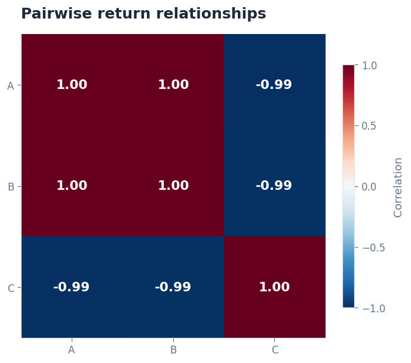

```python
# 绘图代码：先运行本册主题初始化格。
returns = df[["A", "B", "C"]]
valid = returns.notna().astype(int)
pair_counts = valid.T.dot(valid)  # 每格相关性使用的共同非空样本数
print("Pairwise valid observation counts")
display(pair_counts)
corr = returns.corr(min_periods=3)

plt.figure(figsize=(6.5, 5.2))
plt.grid(False)
plt.imshow(corr, cmap="RdBu_r", vmin=-1, vmax=1, interpolation="nearest")
plt.xticks(range(len(corr)), corr.columns)
plt.yticks(range(len(corr)), corr.index)
for row in range(len(corr)):
    for column in range(len(corr)):
        value = corr.iloc[row, column]
        label = "NA" if pd.isna(value) else "{:.2f}".format(value)
        color = "white" if pd.notna(value) and abs(value) > 0.55 else INK
        plt.text(column, row, label, ha="center", va="center",
                 color=color, fontsize=13, fontweight="bold")
plt.colorbar(ticks=[-1, -0.5, 0, 0.5, 1], label="Correlation", shrink=0.80, pad=0.04)
plt.title("Pairwise return relationships")
plt.tight_layout()
plt.show()
```

**美化了哪里：** 相关热图固定 −1 到 +1 的色标，每格显示两位小数，文字颜色随底色深浅变化；共同样本数继续单独展示。

**图怎么读：** A 与 B 正相关，C 与它们负相关；A–B 和 A–C 各有 7 对观测，B–C 只有 6 对。

**换数据时注意：** 相关性不表示因果；缺失模式不同会让各格子使用不同日期，必须一起检查样本数。

## S10 · 今日收益与下一交易日收益散点图

**输入表：`df`（全部 8 行）**

| date | ret |
| --- | --- |
| 2024-01-02 | 0.012 |
| 2024-01-03 | -0.008 |
| 2024-01-04 | 0.006 |
| 2024-01-05 | -0.015 |
| 2024-01-08 | 0.004 |
| 2024-01-09 | 0.011 |
| 2024-01-10 | -0.003 |
| 2024-01-11 | 0.007 |

date 是同一资产不重复、无缺交易日的日期；ret 是日收益的小数，例如 0.012 表示 1.2%。

**要做什么：** 把今日收益放在横轴，下一交易日收益放在纵轴，观察两者是否存在明显关系。

**代码：** 已有同列名的 `df` 时，跳过第一个示例建表格，复制第二个绘图格。

```python
# 示例建表：已有自己的 df 时跳过。
df = pd.DataFrame([
    ['2024-01-02', 0.012],
    ['2024-01-03', -0.008],
    ['2024-01-04', 0.006],
    ['2024-01-05', -0.015],
    ['2024-01-08', 0.004],
    ['2024-01-09', 0.011],
    ['2024-01-10', -0.003],
    ['2024-01-11', 0.007],
], columns=['date', 'ret'])
```

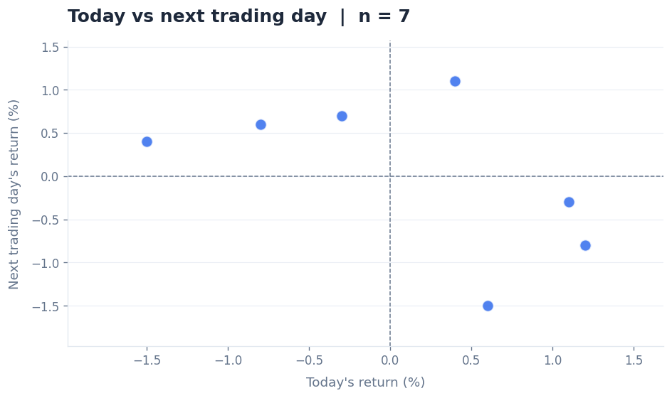

```python
# 绘图代码：先运行本册主题初始化格。
df["date"] = pd.to_datetime(df["date"])
df = df.sort_values("date").copy()
df["next_ret"] = df["ret"].shift(-1)  # 下一交易日收益，只用于事后观察
pairs = df[["ret", "next_ret"]].dropna()  # 成对删除缺失，不分别删两列

plt.figure(figsize=(8, 4.8))
plt.scatter(pairs["ret"] * 100, pairs["next_ret"] * 100,
            s=95, color=BLUE, alpha=0.8, edgecolors="white", linewidths=1.2, zorder=3)
plt.axhline(0, color=MUTED, linewidth=0.9, linestyle="--")
plt.axvline(0, color=MUTED, linewidth=0.9, linestyle="--")
plt.title("Today vs next trading day  |  n = {}".format(len(pairs)))
plt.xlabel("Today's return (%)")
plt.ylabel("Next trading day's return (%)")
plt.margins(0.18)
plt.tight_layout()
plt.show()
```

**美化了哪里：** 用半透明蓝点、白色描边和浅灰零线突出点云，同时在标题注明有效配对数。

**图怎么读：** 每个点是一对相邻交易日的收益；点云形状可以提示后续要检验的关系。

**换数据时注意：** 这里只有 7 对观测，不能据此判断预测能力；若日期有缺口，下一行不一定是下一交易日。

## S11 · 收益自相关柱状图

**输入表：`df`（全部 10 行）**

| date | ret |
| --- | --- |
| 2024-01-02 | 0.012 |
| 2024-01-03 | -0.008 |
| 2024-01-04 | 0.006 |
| 2024-01-05 | -0.015 |
| 2024-01-08 | 0.004 |
| 2024-01-09 | 0.011 |
| 2024-01-10 | -0.003 |
| 2024-01-11 | 0.007 |
| 2024-01-12 | -0.006 |
| 2024-01-15 | 0.002 |

date 是同一资产完整的交易日序列；ret 是收益小数，此例以交易日观测数作为滞后单位。

**要做什么：** 计算收益与前 1、2、3 个交易日收益的相关系数，并画成柱状图。

**代码：** 已有同列名的 `df` 时，跳过第一个示例建表格，复制第二个绘图格。

```python
# 示例建表：已有自己的 df 时跳过。
df = pd.DataFrame([
    ['2024-01-02', 0.012],
    ['2024-01-03', -0.008],
    ['2024-01-04', 0.006],
    ['2024-01-05', -0.015],
    ['2024-01-08', 0.004],
    ['2024-01-09', 0.011],
    ['2024-01-10', -0.003],
    ['2024-01-11', 0.007],
    ['2024-01-12', -0.006],
    ['2024-01-15', 0.002],
], columns=['date', 'ret'])
```

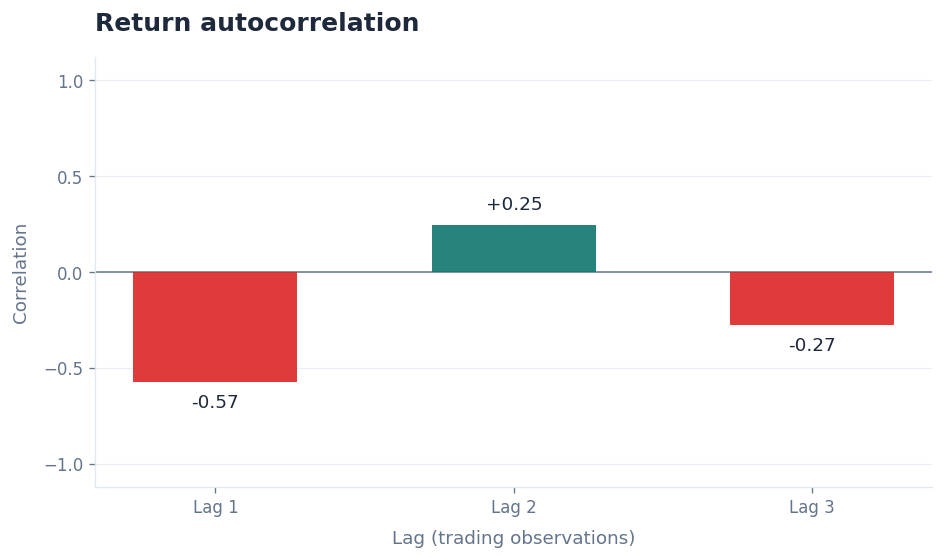

```python
# 绘图代码：先运行本册主题初始化格。
df["date"] = pd.to_datetime(df["date"])
ret = df.sort_values("date")["ret"]
lags = [1, 2, 3]
correlations = [ret.autocorr(lag=k) for k in lags]
colors = [TEAL if value >= 0 else RED for value in correlations]

plt.figure(figsize=(8, 4.8))
plt.bar(lags, correlations, color=colors, width=0.55, alpha=0.9, zorder=3)
plt.axhline(0, color=MUTED, linewidth=0.9)
for lag, value in zip(lags, correlations):
    if pd.notna(value):  # 常数列等情况可能得不到相关系数
        plt.annotate("{:+.2f}".format(value), (lag, value),
                     xytext=(0, 7 if value >= 0 else -7), textcoords="offset points",
                     ha="center", va="bottom" if value >= 0 else "top", color=INK)
plt.xticks(lags, ["Lag {}".format(k) for k in lags])
plt.yticks([-1, -0.5, 0, 0.5, 1])
plt.ylim(-1.12, 1.12)
plt.title("Return autocorrelation")
plt.xlabel("Lag (trading observations)")
plt.ylabel("Correlation")
plt.tight_layout()
plt.show()
```

**美化了哪里：** 正负相关分色，直接标注系数，并保留固定相关系数刻度方便比较。

**图怎么读：** 每根柱子显示一个滞后的相关系数，正负号分别表示同向和反向关系。

**换数据时注意：** 10 条数据仅用于演示代码，没有置信区间；柱子较高也不能说明存在稳定规律。

## S12 · 不同星期的收益箱线图

**输入表：`df`（全部 10 行）**

| date | ret |
| --- | --- |
| 2024-01-08 | 0.012 |
| 2024-01-09 | -0.006 |
| 2024-01-10 | 0.003 |
| 2024-01-11 | -0.009 |
| 2024-01-12 | 0.007 |
| 2024-01-15 | -0.005 |
| 2024-01-16 | 0.004 |
| 2024-01-17 | -0.002 |
| 2024-01-18 | 0.006 |
| 2024-01-19 | 0.001 |

date 是日收益所属的交易日期，ret 是收益小数；本例每个星期类别恰有两条记录。

**要做什么：** 按星期一到星期五分组，用箱线图比较各组收益的分布。

**代码：** 已有同列名的 `df` 时，跳过第一个示例建表格，复制第二个绘图格。

```python
# 示例建表：已有自己的 df 时跳过。
df = pd.DataFrame([
    ['2024-01-08', 0.012],
    ['2024-01-09', -0.006],
    ['2024-01-10', 0.003],
    ['2024-01-11', -0.009],
    ['2024-01-12', 0.007],
    ['2024-01-15', -0.005],
    ['2024-01-16', 0.004],
    ['2024-01-17', -0.002],
    ['2024-01-18', 0.006],
    ['2024-01-19', 0.001],
], columns=['date', 'ret'])
```

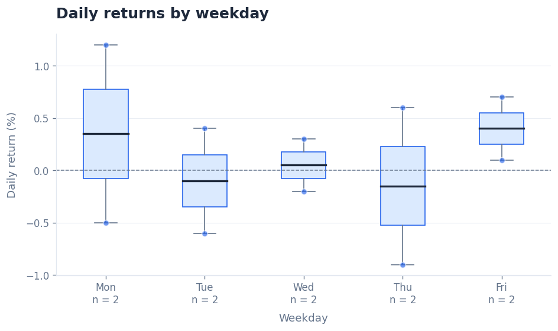

```python
# 绘图代码：先运行本册主题初始化格。
df["date"] = pd.to_datetime(df["date"])
df = df.sort_values("date")
weekday = df["date"].dt.dayofweek  # 周一=0，周五=4
groups = [df.loc[weekday == k, "ret"].dropna() * 100 for k in range(5)]
names = ["Mon", "Tue", "Wed", "Thu", "Fri"]
labels = ["{}\nn = {}".format(name, len(group)) for name, group in zip(names, groups)]

plt.figure(figsize=(8, 4.8))
plt.boxplot(groups, widths=0.45, patch_artist=True, showfliers=False,
            boxprops={"facecolor": "#DBEAFE", "edgecolor": BLUE},
            medianprops={"color": INK, "linewidth": 2},
            whiskerprops={"color": MUTED}, capprops={"color": MUTED})
for position, group in enumerate(groups, start=1):
    plt.scatter([position] * len(group), group, s=35, color=BLUE,
                alpha=0.65, edgecolors="white", zorder=3)  # 原始点包括离群值
plt.xticks(range(1, 6), labels)
plt.axhline(0, color=MUTED, linewidth=0.9, linestyle="--")
plt.title("Daily returns by weekday")
plt.xlabel("Weekday")
plt.ylabel("Daily return (%)")
plt.tight_layout()
plt.show()
```

**美化了哪里：** 用浅蓝箱体、深色中位线和原始观测点呈现分布，星期标签同时显示真实样本数。

**图怎么读：** 箱体和中位线用于比较各组分布；本例每组只有两个点，形状只是绘图示意。

**换数据时注意：** 真实分析需要更多样本和分期检验；不要从这 10 条数据推断星期效应。

## S13 · 月度收益热力图

**输入表：`df`（全部 8 行）**

| month | monthly_ret |
| --- | --- |
| 2023-01-01 | 0.025 |
| 2023-02-01 | -0.018 |
| 2023-03-01 | 0.01 |
| 2023-04-01 | 0.036 |
| 2024-03-01 | -0.028 |
| 2024-04-01 | 0.014 |
| 2024-05-01 | -0.007 |
| 2024-06-01 | 0.022 |

每行已是一个完整月份的复合收益，monthly_ret 为小数；每月只有一行，未提供的月份保留缺失。

**要做什么：** 把年份放在行、月份放在列，用颜色展示每个月的收益。

**代码：** 已有同列名的 `df` 时，跳过第一个示例建表格，复制第二个绘图格。

```python
# 示例建表：已有自己的 df 时跳过。
df = pd.DataFrame([
    ['2023-01-01', 0.025],
    ['2023-02-01', -0.018],
    ['2023-03-01', 0.01],
    ['2023-04-01', 0.036],
    ['2024-03-01', -0.028],
    ['2024-04-01', 0.014],
    ['2024-05-01', -0.007],
    ['2024-06-01', 0.022],
], columns=['month', 'monthly_ret'])
```

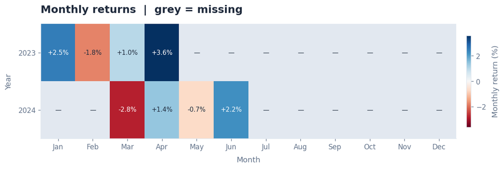

```python
# 绘图代码：先运行本册主题初始化格。
df["month"] = pd.to_datetime(df["month"])
df = df.sort_values("month")
table = df.assign(year=df["month"].dt.year, month_number=df["month"].dt.month).pivot(
    index="year", columns="month_number", values="monthly_ret")
table = table.reindex(columns=range(1, 13)) * 100  # 缺月保持 NaN，收益转百分数
limit = table.abs().max().max()
limit = limit if pd.notna(limit) and limit > 0 else 1  # 全零或全缺失时仍能画图
cmap = plt.get_cmap("RdBu").copy()
cmap.set_bad(LIGHT)  # 灰色代表缺失，不能填成零收益

plt.figure(figsize=(11, max(3.5, len(table) * 0.6 + 1.8)))
plt.imshow(table, aspect="auto", cmap=cmap, vmin=-limit, vmax=limit)
for row in range(len(table)):
    for col in range(12):
        value = table.iloc[row, col]
        label = "—" if pd.isna(value) else "{:+.1f}%".format(value)
        color = "white" if pd.notna(value) and abs(value) > limit * 0.6 else INK
        plt.text(col, row, label, ha="center", va="center", color=color, fontsize=9)
plt.colorbar(label="Monthly return (%)", shrink=0.8, pad=0.02)
plt.xticks(range(12), ["Jan", "Feb", "Mar", "Apr", "May", "Jun", "Jul", "Aug", "Sep", "Oct", "Nov", "Dec"])
plt.yticks(range(len(table)), table.index)
plt.grid(False)
plt.title("Monthly returns  |  grey = missing")
plt.xlabel("Month")
plt.ylabel("Year")
plt.tight_layout()
plt.show()
```

**美化了哪里：** 使用以零为中心的对称色阶、格内百分数和灰色缺失格，明确区分零收益与未提供数据。

**图怎么读：** 蓝色表示正收益，红色表示负收益；灰色横杠表示未提供该月数据，不表示收益为零。

**换数据时注意：** 先确认日数据覆盖完整月份再计算月收益；此模板只负责绘制已经验证的月收益。

## S14 · 每日成交量柱状图

**输入表：`df`（全部 8 行）**

| date | volume |
| --- | --- |
| 2024-01-02 | 1250000 |
| 2024-01-03 | 1180000 |
| 2024-01-04 | 1420000 |
| 2024-01-05 | 3200000 |
| 2024-01-08 | 1670000 |
| 2024-01-09 | 1360000 |
| 2024-01-10 | 1210000 |
| 2024-01-11 | 1490000 |

date 是同一资产的日期，volume 是当日成交股数；如果原数据是手数或成交额，需要相应修改纵轴单位。

**要做什么：** 画每日成交量，找出明显放量的日期。

**代码：** 已有同列名的 `df` 时，跳过第一个示例建表格，复制第二个绘图格。

```python
# 示例建表：已有自己的 df 时跳过。
df = pd.DataFrame([
    ['2024-01-02', 1250000],
    ['2024-01-03', 1180000],
    ['2024-01-04', 1420000],
    ['2024-01-05', 3200000],
    ['2024-01-08', 1670000],
    ['2024-01-09', 1360000],
    ['2024-01-10', 1210000],
    ['2024-01-11', 1490000],
], columns=['date', 'volume'])
```

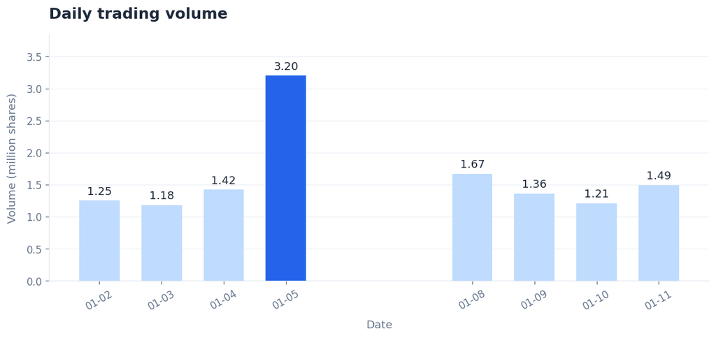

```python
# 绘图代码：先运行本册主题初始化格。
df["date"] = pd.to_datetime(df["date"])
df = df.sort_values("date")
volume_m = df["volume"] / 1000000  # 单位由股转换为百万股
colors = [BLUE if value == volume_m.max() else "#BFDBFE" for value in volume_m]

plt.figure(figsize=(10, 4.8))
plt.bar(df["date"], volume_m, color=colors, width=0.65, zorder=3)
for date, value in zip(df["date"], volume_m):
    if pd.notna(value):
        plt.annotate("{:.2f}".format(value), (date, value),
                     xytext=(0, 6), textcoords="offset points", ha="center", color=INK)
max_volume = volume_m.max()
upper = max(max_volume * 1.2, 1) if pd.notna(max_volume) else 1
plt.ylim(0, upper)  # 全缺失时保留空图，不把缺失成交量改成 0
plt.title("Daily trading volume")
plt.xlabel("Date")
plt.ylabel("Volume (million shares)")
plt.xticks(df["date"], df["date"].dt.strftime("%m-%d"), rotation=30)
plt.tight_layout()
plt.show()
```

**美化了哪里：** 普通日期用浅蓝色，最大成交量用深蓝突出，并在柱顶直接显示百万股数值。

**图怎么读：** 示例中 1 月 5 日的柱子明显更高，可以回到原始记录检查当天发生了什么。

**换数据时注意：** 周末留白属于日期轴的正常间隔；成交量增加本身不说明未来价格会上涨。

## S15 · 在时间序列上标出训练与测试边界

**输入表：`df`（全部 8 行）**

| date | value |
| --- | --- |
| 2024-01-02 | 100 |
| 2024-01-03 | 102 |
| 2024-01-04 | 101 |
| 2024-01-05 | 104 |
| 2024-01-08 | 103 |
| 2024-01-09 | 106 |
| 2024-01-10 | 105 |
| 2024-01-11 | 108 |

date 是观测日期，value 是要检查的数值；本例约定 2024-01-08 起的数据属于测试区间。

**要做什么：** 画出时间序列，并在测试集开始的日期画一条竖线。

**代码：** 已有同列名的 `df` 时，跳过第一个示例建表格，复制第二个绘图格。

```python
# 示例建表：已有自己的 df 时跳过。
df = pd.DataFrame([
    ['2024-01-02', 100],
    ['2024-01-03', 102],
    ['2024-01-04', 101],
    ['2024-01-05', 104],
    ['2024-01-08', 103],
    ['2024-01-09', 106],
    ['2024-01-10', 105],
    ['2024-01-11', 108],
], columns=['date', 'value'])
```

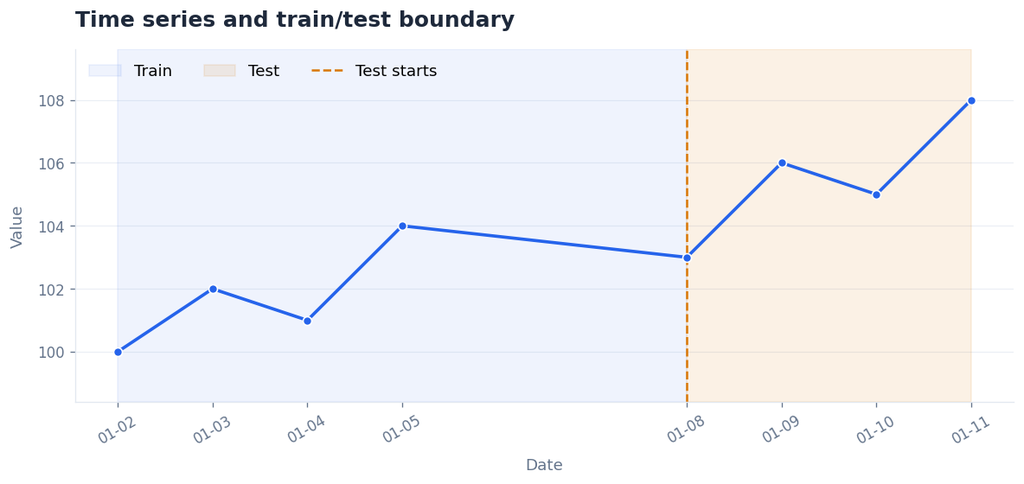

```python
# 绘图代码：先运行本册主题初始化格。
df["date"] = pd.to_datetime(df["date"])
df = df.sort_values("date")
test_start = pd.Timestamp("2024-01-08")  # 改成预先确定的测试起点，当天属于测试集

plt.figure(figsize=(10, 4.8))
plt.axvspan(df["date"].min(), test_start, color=BLUE, alpha=0.07, label="Train")
plt.axvspan(test_start, df["date"].max(), color=ORANGE, alpha=0.10, label="Test")
plt.plot(df["date"], df["value"], color=BLUE, linewidth=2.2,
         marker="o", markersize=6, markeredgecolor="white", zorder=3)
plt.axvline(test_start, color=ORANGE, linestyle="--", linewidth=1.5, label="Test starts")
plt.title("Time series and train/test boundary")
plt.xlabel("Date")
plt.ylabel("Value")
plt.legend(loc="upper left", ncol=3)
plt.margins(y=0.2)
plt.xticks(df["date"], df["date"].dt.strftime("%m-%d"), rotation=30)
plt.tight_layout()
plt.show()
```

**美化了哪里：** 用两块浅色背景区分训练与测试，边界用虚线标出，时间序列保持同一条清晰折线。

**图怎么读：** 橙色切分线之前为训练区间，切分线当天及之后为测试区间；浅色背景帮助辨认范围。

**换数据时注意：** 画边界不等于已消除泄漏；预处理参数仍须只从训练集估计，跨边界的预测标签也须处理。

## S16 · 不同特征分组的下一期平均收益

**输入表：`df`（全部 9 行）**

| bucket | next_ret |
| --- | --- |
| Low | -0.01 |
| Low | 0.004 |
| Low | -0.003 |
| Mid | 0.002 |
| Mid | -0.004 |
| Mid | 0.005 |
| High | 0.008 |
| High | -0.002 |
| High | 0.006 |

bucket 是使用当时可知特征和事先固定规则得到的组别；next_ret 为下一期收益小数，仅用于事后评估。

**要做什么：** 比较 Low、Mid、High 三组的下一期平均收益，同时列出每组有效样本数。

**代码：** 已有同列名的 `df` 时，跳过第一个示例建表格，复制第二个绘图格。

```python
# 示例建表：已有自己的 df 时跳过。
df = pd.DataFrame([
    ['Low', -0.01],
    ['Low', 0.004],
    ['Low', -0.003],
    ['Mid', 0.002],
    ['Mid', -0.004],
    ['Mid', 0.005],
    ['High', 0.008],
    ['High', -0.002],
    ['High', 0.006],
], columns=['bucket', 'next_ret'])
```

| bucket | 平均收益（小数） | 有效样本数 |
| --- | --- | --- |
| Low | -0.003 | 3 |
| Mid | 0.001 | 3 |
| High | 0.004 | 3 |

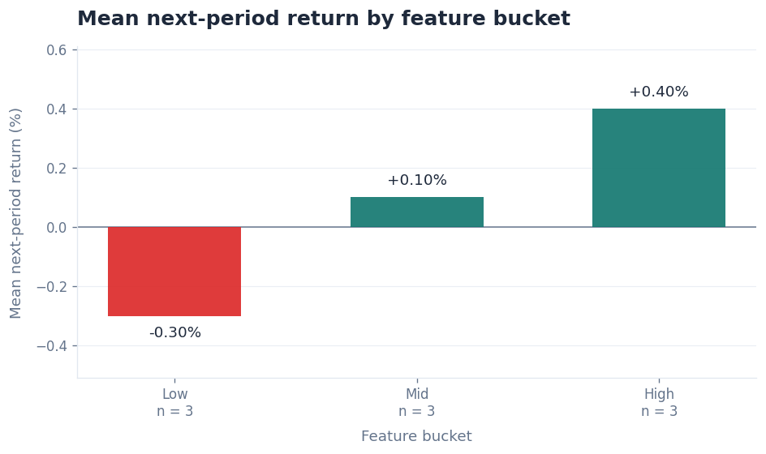

```python
# 绘图代码：先运行本册主题初始化格。
summary = df.groupby("bucket")["next_ret"].agg(["mean", "count"])
summary = summary.reindex(["Low", "Mid", "High"])
display(summary.rename(columns={"mean": "平均收益（小数）", "count": "有效样本数"}))
mean_pct = summary["mean"] * 100
colors = [TEAL if value >= 0 else RED for value in mean_pct]
labels = ["{}\nn = {}".format(group, int(count)) for group, count in summary["count"].fillna(0).items()]

plt.figure(figsize=(8, 4.8))
plt.bar(range(len(summary)), mean_pct, color=colors, width=0.55, alpha=0.9, zorder=3)
plt.axhline(0, color=MUTED, linewidth=0.9)
for position, value in enumerate(mean_pct):
    if pd.notna(value):
        plt.annotate("{:+.2f}%".format(value), (position, value),
                     xytext=(0, 7 if value >= 0 else -7), textcoords="offset points",
                     ha="center", va="bottom" if value >= 0 else "top", color=INK)
plt.xticks(range(len(summary)), labels)
plt.margins(y=0.3)
plt.title("Mean next-period return by feature bucket")
plt.xlabel("Feature bucket")
plt.ylabel("Mean next-period return (%)")
plt.tight_layout()
plt.show()
```

**美化了哪里：** 均值柱按正负分色，直接标出百分数与每组有效样本数，减少来回查表。

**图怎么读：** 柱子比较各组的下一期平均收益；同时看表中样本数，避免把少量观测的均值当作稳定效果。

**换数据时注意：** 分组规则不能根据这些未来收益反向选择；图中关系尚未检验显著性、交易成本或样本外表现。

## S17 · 从日收益计算并画回撤

**输入表：`df`（全部 8 行）**

| date | ret |
| --- | --- |
| 2024-01-02 | -0.02 |
| 2024-01-03 | 0.01 |
| 2024-01-04 | 0.03 |
| 2024-01-05 | -0.04 |
| 2024-01-08 | -0.015 |
| 2024-01-09 | 0.02 |
| 2024-01-10 | 0.01 |
| 2024-01-11 | 0.035 |

date 是唯一且完整的日期序列；ret 是不含缺失、均大于 -1 的日收益小数，初始净值设为 1。

**要做什么：** 把日收益复合成净值，计算相对历史最高净值的跌幅，并画回撤曲线。

**代码：** 已有同列名的 `df` 时，跳过第一个示例建表格，复制第二个绘图格。

```python
# 示例建表：已有自己的 df 时跳过。
df = pd.DataFrame([
    ['2024-01-02', -0.02],
    ['2024-01-03', 0.01],
    ['2024-01-04', 0.03],
    ['2024-01-05', -0.04],
    ['2024-01-08', -0.015],
    ['2024-01-09', 0.02],
    ['2024-01-10', 0.01],
    ['2024-01-11', 0.035],
], columns=['date', 'ret'])
```

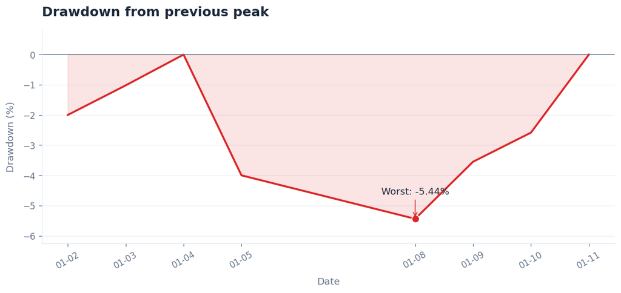

```python
# 绘图代码：先运行本册主题初始化格。
df["date"] = pd.to_datetime(df["date"])
df = df.sort_values("date").reset_index(drop=True)
wealth = (1 + df["ret"]).cumprod()
peak = wealth.cummax().clip(lower=1)  # 初始净值为 1，首日亏损也应计入回撤
drawdown_pct = (wealth / peak - 1) * 100
worst = drawdown_pct.idxmin()

plt.figure(figsize=(10, 4.8))
plt.fill_between(df["date"], drawdown_pct, 0, color=RED, alpha=0.12)
plt.plot(df["date"], drawdown_pct, color=RED, linewidth=2.2)
plt.axhline(0, color=MUTED, linewidth=0.9)
plt.scatter(df.loc[worst, "date"], drawdown_pct.loc[worst], color=RED,
            s=75, edgecolors="white", zorder=3)
plt.annotate("Worst: {:.2f}%".format(drawdown_pct.loc[worst]),
             (df.loc[worst, "date"], drawdown_pct.loc[worst]),
             xytext=(0, 28), textcoords="offset points", ha="center", color=INK,
             arrowprops={"arrowstyle": "->", "color": RED})
plt.title("Drawdown from previous peak")
plt.xlabel("Date")
plt.ylabel("Drawdown (%)")
plt.margins(y=0.15)
plt.xticks(df["date"], df["date"].dt.strftime("%m-%d"), rotation=30)
plt.tight_layout()
plt.show()
```

**美化了哪里：** 柔和红色面积呈现回撤深度，用深红曲线和箭头标签指出区间最深回撤。

**图怎么读：** 曲线越低，距离此前最高净值越远；本例第一天亏损也会正确显示为负回撤。

**换数据时注意：** 缺失收益不能默认填零；若输入为策略收益，还须明确是否已扣除交易成本。

## S18 · 每小时事件数量柱状图

**输入表：`df`（全部 8 行）**

| timestamp |
| --- |
| 2024-01-08 09:10:00 |
| 2024-01-08 09:42:00 |
| 2024-01-08 10:15:00 |
| 2024-01-08 12:05:00 |
| 2024-01-08 12:20:00 |
| 2024-01-08 12:51:00 |
| 2024-01-08 13:08:00 |
| 2024-01-08 14:25:00 |

每行是一条事件；timestamp 使用同一时区，本例确认当天 09:00 至 15:00 的采集持续完整。

**要做什么：** 按小时统计事件条数，并显示完全没有事件的小时。

**代码：** 已有同列名的 `df` 时，跳过第一个示例建表格，复制第二个绘图格。

```python
# 示例建表：已有自己的 df 时跳过。
df = pd.DataFrame([
    ['2024-01-08 09:10:00'],
    ['2024-01-08 09:42:00'],
    ['2024-01-08 10:15:00'],
    ['2024-01-08 12:05:00'],
    ['2024-01-08 12:20:00'],
    ['2024-01-08 12:51:00'],
    ['2024-01-08 13:08:00'],
    ['2024-01-08 14:25:00'],
], columns=['timestamp'])
```

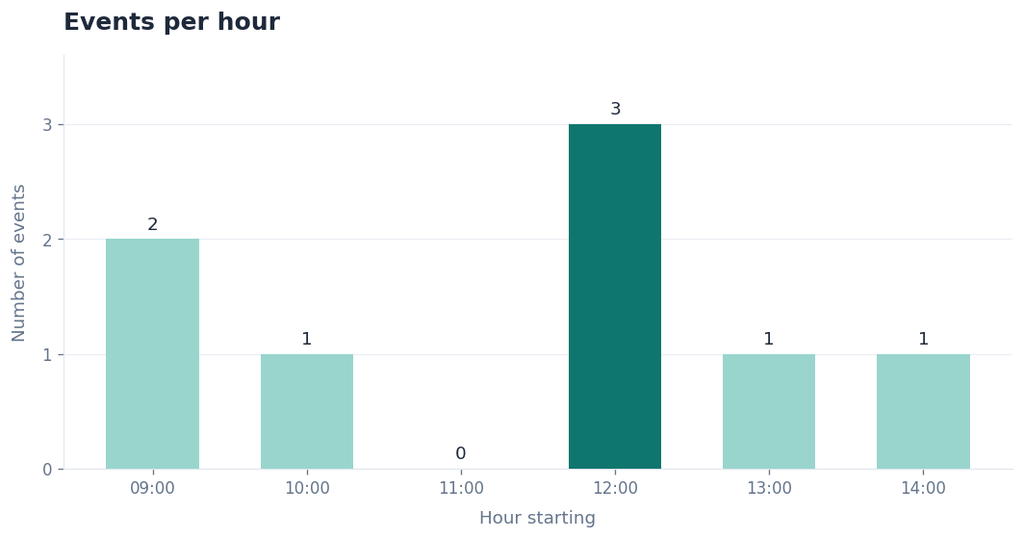

```python
# 绘图代码：先运行本册主题初始化格。
events = df.assign(timestamp=pd.to_datetime(df["timestamp"]))
events = events.sort_values("timestamp")
counts = events.set_index("timestamp").resample("1h").size()
# 替换成实际已确认完整采集的起止小时；本例最后一格覆盖 14:00–15:00。
hours = pd.date_range("2024-01-08 09:00", "2024-01-08 14:00", freq="1h")
counts = counts.reindex(hours, fill_value=0)  # 只有采集完整时，空小时才能记为零
colors = [TEAL if value == counts.max() else "#99D5CD" for value in counts]

plt.figure(figsize=(9, 4.8))
plt.bar(range(len(counts)), counts.values, color=colors, width=0.6, zorder=3)
for position, value in enumerate(counts):
    plt.annotate(str(value), (position, value), xytext=(0, 6),
                 textcoords="offset points", ha="center", color=INK)
plt.xticks(range(len(counts)), counts.index.strftime("%H:%M"))
plt.yticks(range(int(counts.max()) + 1))
plt.ylim(0, max(counts.max() * 1.2, 1))
plt.title("Events per hour")
plt.xlabel("Hour starting")
plt.ylabel("Number of events")
plt.tight_layout()
plt.show()
```

**美化了哪里：** 用青色突出事件最多的小时，柱顶标出计数，零事件小时保留标签和整数纵轴。

**图怎么读：** 12 点这一小时有三条事件，11 点这一小时为零，方便观察事件到达是否均匀。

**换数据时注意：** 只有确认采集完整时，空小时才可记为零；采集故障导致的缺失必须另行标记。

## 改成自己的样式

常用的几处修改：`figsize` 调整大小；`color` 改颜色；`alpha` 调整透明度；`marker` 控制数据点；`plt.title()` 和轴标签说明单位。主题格的字号和网格设置会作用于之后新建的图。

小表适合逐点标注；换成几千行数据时只保留末值、极值或少量重点标签，必要时去掉 `marker`。类别过多时选择有依据的展示子集，不把所有文字挤进一张图。需要恢复 Matplotlib 默认外观时，运行 `plt.rcdefaults()`。

**保存图片：** 在所选案例的 `plt.show()` 前加入下面这一行。文件名自行改写，重复使用同名文件会覆盖旧图。

```
plt.savefig("my_chart.png", dpi=200, bbox_inches="tight", facecolor="white")
```

返回基础版 · [Matplotlib pyplot 文档](https://matplotlib.org/3.7.5/tutorials/introductory/pyplot.html)